# 데이터마이닝을 활용한 영화 관객수 예측 모델

[output not shown]

[output not shown]

[output not shown]

[output not shown]

[output not shown]

[output not shown]

[output not shown]

### 1. 서론

#### 1.1 연구 목적

영화 산업: 문화산업적 성격을 가지고 있는 21세기의 고부가가치 산업 중 하나.

1. 관객수 예측에 주요 변수를 고려
2. 영화 흥행을 판단하는 관객수를 예측.
3. 데이터 마이닝 기법 활용한 예측 모델 생성 후 성능 비교

#### 1.2 선행연구

1. 다중회귀분석을 이용한 흥행 예측 (정희운,양형정)

-> 다중회귀분석을 통해 도출한 유의한 변수 ‘개봉 첫날 스크린 수’, ‘국적’, ‘제작사’, ‘배급 사’, ‘배우’, ‘상영시간’으로 분석을 진행 (다중회귀분석,의사결정나무, 인공신경망을 비교)

2. 영화 유형별 영화 흥행 성과 예측 요인의 비교 연구: 예술 영화와 상업 영화 비교를 중심으로(김소영, 임승희,정예슬)

-> 회귀식을 통해 스크린수, 관객 평가, 장르변수가 “상업/예술영화”에 유의미한 변수.

3. 베이지안 선택 모형을 이용한 영화 흥행 예측(이경재, 장우진)

-> 영화간 ,이질성을 고려할 수 있는 베이지안 선택 모형을 제안

-> 감독, 배우, 장르 등의 영화 별 속성 변수뿐만 아니라 입소문에 의한 영화관람 결정 등의 구전효과와 경쟁영화의 개봉으로 인한 효과를 반영할 수 있는 변수를 추가하여 모형의 정확성을 높임.

-> 인공신경망보다 베이지안 모형이 더 우수한 결과를 얻음. 스크린 수가 가장 중요한 변수.

4. 영화 흥행성과의 분석과 예측:뉴스와 웹사이트 데이터 이용(권선주)

-> 모든 기간에서 전문가 평점은 국내외 타연구결과에서와 같이 영화흥행과 통계적 유의성이 없음.

-> 스크린수가 주요한 요인

5. 한국영화의 흥행성과 결정 요인에 관한 연구(박승현,송현주,정완)

-> 감독이나 배우의 스타성 여부를 그들이 개봉 시점으로부터 4년 전까지 연출하거나 주연으로 출연했던 영화들 중 1백만 명 이상의 관객을 동원한 영화가 있는가에 따라 결정

6. 데이터마이닝 기법을 활용한 영화 흥행 실적 예측 기법(강지훈,박찬희,동형록,김성범)

-> Decision Tree Model으르 선정하여 활용

7. 한국 영화의 흥행성과 결정요인 분석:2012년 개봉 상업영화를 중심으로(김상호, 한진만)

-> 개봉스크린 규모와 온라인 평가의 평점만 흥행성과에 통계적으로 유의미한 영향력

-> 흥행성과에 영향을 미치는 요인으로 총 9개로 고려 (개봉 스크린규모, 제작비, 배급사 파워, 영화 등급, 영화 장르, 개봉시기, 속편형태, 전문가 평가, 그리고 네티즌의 온라인 평가)

### 2. 본론

#### 2.1 데이터 설명

[output not shown]

### 2.2 변수 설명

```
- 종속변수: 전국관객 수

    범주형 (1: low, 2: middle, 3: high)

    관객수를 크기순로 정렬 후 3등분 한 범주
    low: 34,182 이하, middle: 34,183이상 233,283 이상, high: 233,284 이상


- 독립변수

    1. 전국스크린수

    - 이산형 (18~2553)

    2. 국적

    - 범주형 (0: 국내, 1: 국외)

    3. mov_class

    - 영화 구분
    - 범주형 (0: 상업영화, 1: 다양성영화)
      다양성 영화: 저예산의 독립영화,예술영화와 같은 영화


    4. 'SF', '가족', '공연', '공포.호러', '다큐멘터리', '드라마',                                 '멜로.로맨스','뮤지컬', '미스터리', '범죄', '사극', '스릴러', '애니메이션', '액션'
      , '어드벤처', '전쟁', '코미디', '판타지'

    - 영화 장르
    - 범주형 (1: yes, 0: no)

    5. 제목수

    - 영화 제목 글자수
    - 이산형 (1~35)

    6. '12세이상관람가', '15세이상관람가', '전체관람가', '청소년관람불가'

    - 범주형 (1: yes, 0: no)

```

[output cut: 34 more lines]

```
    - 범주형(1:여름, 0:no)

    14. season3

    - 범주형(1:가을, 0:no)

    15. holiday

    - 이산형 (0~3)
    - 개봉 후 14일 이내에 공휴일의 개수

    16. company

    - 이산형(0~22.9)
    - 개봉년 기준 작년 국내 상위 10개의 배급사 관객 점유율
```

### 2.3 기초 통계

```r
setwd("C:/Users/rok80/Desktop/영화관객수예측모델")
tmp <- readxl::read_xlsx("모델데이터2.xlsx")
```

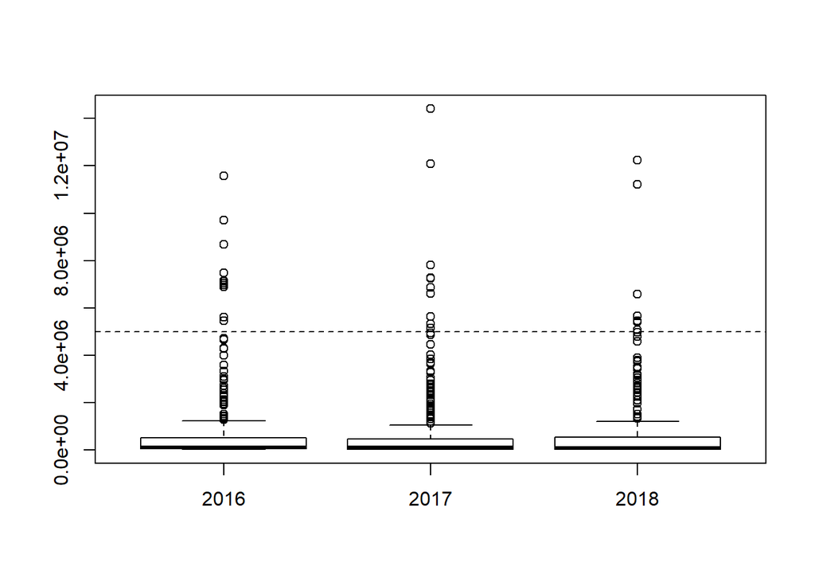

```r
tmp <- readxl::read_xlsx("모델데이터2.xlsx") %>% as.data.frame()

#1. 연도별 관객수
boxplot(전국관객수~year, data=tmp)
abline(h=5000000, lty=2)
```

```r
"전국" <-  mean(tmp[,"전국관객수"])
`2016` <-  mean(tmp[tmp$year=='2016',"전국관객수"])
`2017` <-  mean(tmp[tmp$year=='2017',"전국관객수"])
`2018` <-  mean(tmp[tmp$year=='2018',"전국관객수"])
audience_mean <- data.frame(`2016년`=`2016`,`2017년`=`2017`,`2018년`=`2018`,전국=전국,row.names = "평균 관객수")
colnames(audience_mean) <- c("2016년","2017년","2018년","종합")
audience_mean
```

```
##               2016년   2017년   2018년     종합
## 평균 관객수 710602.2 704375.3 696143.1 704156.2
```

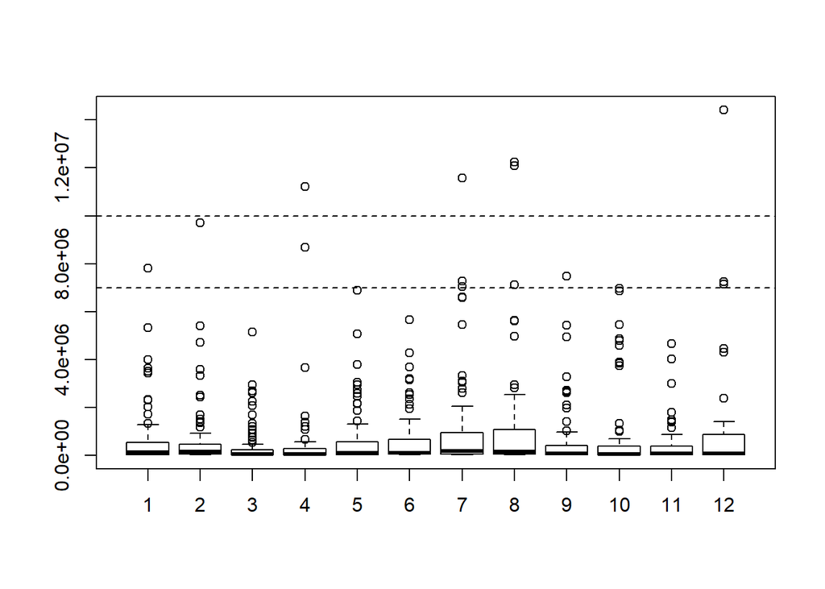

```r
#2. 월별 관객수
boxplot(전국관객수~season, data=tmp)
abline(h=10000000, lty=2)
abline(h=7000000, lty=2)
```

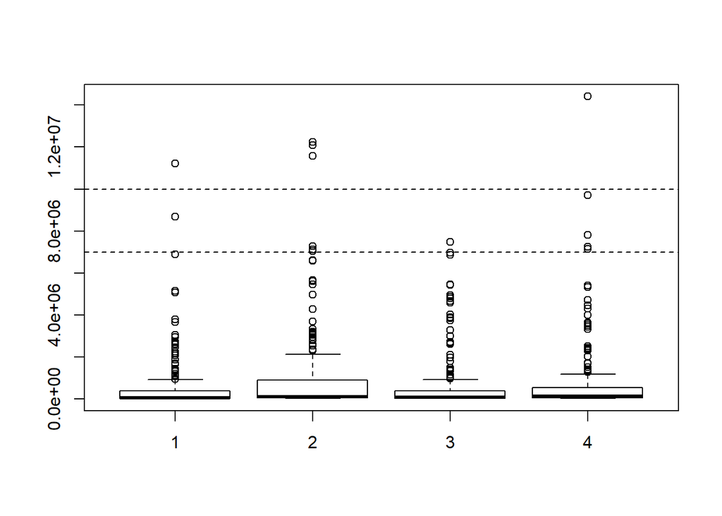

```r
#3. 계절별 관객수
tmp$four_season <- rep(0,nrow(tmp))
tmp[tmp$season1==1,'four_season'] <- 1
tmp[tmp$season2==1,'four_season'] <- 2
tmp[tmp$season3==1,'four_season'] <- 3
tmp[tmp$four_season==0,'four_season'] <- 4
boxplot(전국관객수~four_season, data=tmp) # 계절별 관객수
abline(h=10000000, lty=2)
abline(h=7000000, lty=2)
```

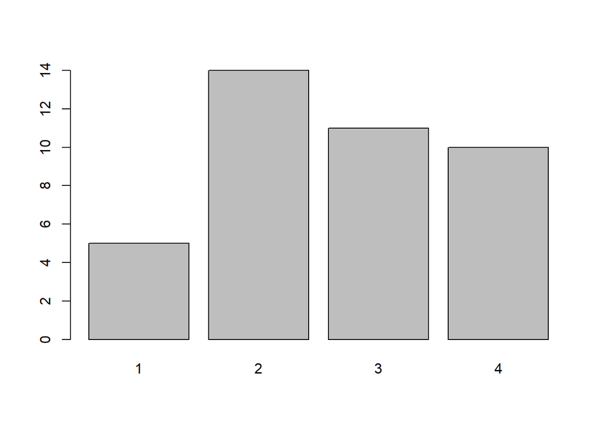

```r
tmp[tmp$전국관객수>=4000000,"four_season"] %>% table() %>% barplot() #계절별 흥행 영화수
```

```r
tmp[tmp$전국관객수>=4000000,"four_season"] %>% table()
```

```
## .
##  1  2  3  4
##  5 14 11 10
```

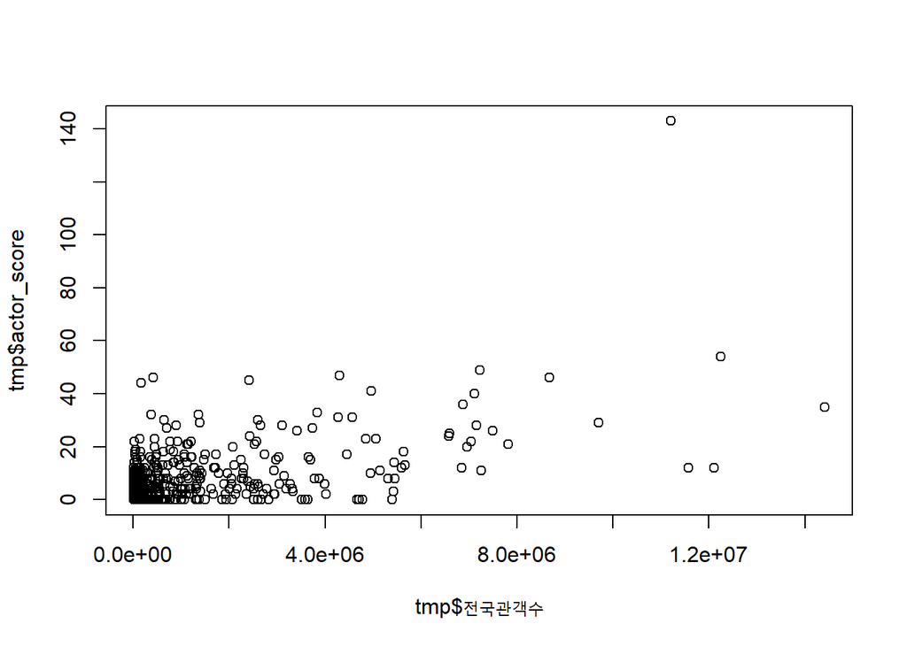

```r
#4. 변수 간 상관관계
plot(tmp$전국관객수,tmp$actor_score)
```

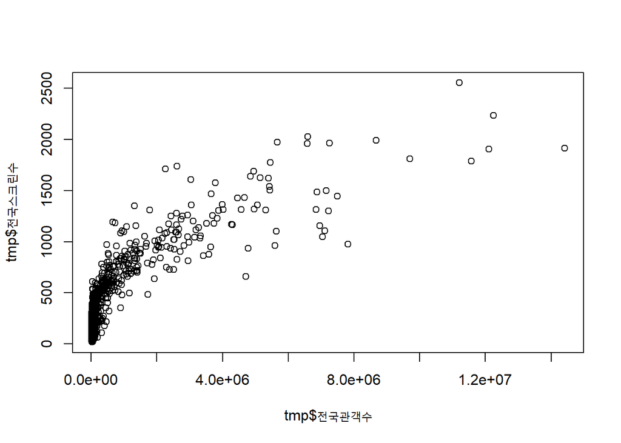

```r
plot(tmp$전국관객수,tmp$전국스크린수)
```

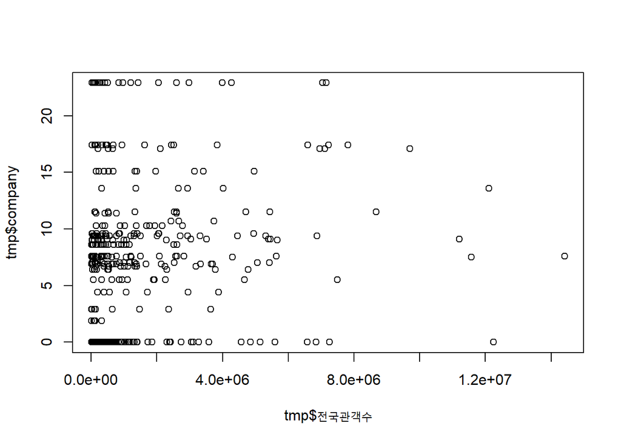

```r
plot(tmp$전국관객수,tmp$company)
```

```r
cor(tmp[,c('y','actor_score','actor_num','up_100','전국스크린수','국적','company','mov_class','액션','애니메이션','제목수')])
```

```
##                       y actor_score   actor_num     up_100 전국스크린수
## y             1.0000000   0.3877925  0.23236564  0.4217413    0.7392955
## actor_score   0.3877925   1.0000000  0.40894233  0.9819774    0.5866128
## actor_num     0.2323656   0.4089423  1.00000000  0.4238440    0.3323386
## up_100        0.4217413   0.9819774  0.42384404  1.0000000    0.6078926
## 전국스크린수  0.7392955   0.5866128  0.33233863  0.6078926    1.0000000
## 국적         -0.2448002  -0.2747785  0.03436083 -0.2750363   -0.2655012
## company       0.5054732   0.3152412  0.17055487  0.3214054    0.5008955
## mov_class     0.5700884   0.2941816  0.21499047  0.3234136    0.5462088
## 액션          0.2122529   0.2006882  0.20962582  0.2376596    0.3203093
## 애니메이션   -0.1114266  -0.2409953 -0.08412703 -0.2677302   -0.1434011
## 제목수       -0.1313881  -0.1747147  0.04588355 -0.1899930   -0.1507713
##                     국적     company   mov_class        액션  애니메이션
## y            -0.24480021  0.50547320  0.57008839  0.21225295 -0.11142659
## actor_score  -0.27477853  0.31524119  0.29418165  0.20068822 -0.24099526
## actor_num     0.03436083  0.17055487  0.21499047  0.20962582 -0.08412703
## up_100       -0.27503629  0.32140540  0.32341361  0.23765956 -0.26773023
## 전국스크린수 -0.26550115  0.50089550  0.54620882  0.32030928 -0.14340111
## 국적          1.00000000 -0.19278896 -0.19791620  0.15761686  0.20317337
## company      -0.19278896  1.00000000  0.46667934  0.07855876 -0.03005551
## mov_class    -0.19791620  0.46667934  1.00000000  0.23375212 -0.01643551
## 액션          0.15761686  0.07855876  0.23375212  1.00000000 -0.23290759
## 애니메이션    0.20317337 -0.03005551 -0.01643551 -0.23290759  1.00000000
## 제목수        0.25108452 -0.01365372  0.04870751 -0.01250059  0.44898719
##                   제목수
## y            -0.13138811
## actor_score  -0.17471467
## actor_num     0.04588355
## up_100       -0.18999298
## 전국스크린수 -0.15077134
## 국적          0.25108452
## company      -0.01365372
## mov_class     0.04870751
## 액션         -0.01250059
## 애니메이션    0.44898719
## 제목수        1.00000000
```

### 2.4 모델 생성 및 결과 해석

#### 2.4.1 의사결정나무

```r
library(rpart)
tmp <- readxl::read_xlsx("모델데이터2.xlsx")
tmp$y <- factor(tmp$y)
idx <- which(tmp$year=="2018") # 2018년 데이터만
train <- tmp[-idx,]
test <- tmp[idx,]
train <- train[,-c(1,2,4)]# 불필요 변수 삭제
test <- test[,-c(1,2,4)]# 불필요 변수 삭제
model <- rpart(y~., data=train, method="class")
pred <- predict(model, test)
pred <- as.data.frame(pred)

pred$p <- apply(pred, 1, max)

for(i in 1:nrow(pred)){
  for(j in 1:3){
    if(pred[i,j]==pred[i,"p"]){
      pred[i,"p"] <- j
    }
  }
}
pred$p <- factor(pred$p)
confusionMatrix(pred$p, test$y)
```

```
## Confusion Matrix and Statistics
##
##           Reference
## Prediction  1  2  3
##          1 68 17  1
##          2 26 42  6
##          3  1 14 71
##
## Overall Statistics
##
##                Accuracy : 0.7358
##                  95% CI : (0.676, 0.7898)
##     No Information Rate : 0.3862
##     P-Value [Acc > NIR] : <2e-16
##
##                   Kappa : 0.6026
##  Mcnemar's Test P-Value : 0.1658
##
## Statistics by Class:
##
##                      Class: 1 Class: 2 Class: 3
## Sensitivity            0.7158   0.5753   0.9103
## Specificity            0.8808   0.8150   0.9107
## Pos Pred Value         0.7907   0.5676   0.8256
## Neg Pred Value         0.8312   0.8198   0.9563
## Prevalence             0.3862   0.2967   0.3171
## Detection Rate         0.2764   0.1707   0.2886
## Detection Prevalence   0.3496   0.3008   0.3496
## Balanced Accuracy      0.7983   0.6952   0.9105
```

#### 2.4.2나이브베이지안

```r
tmp <- readxl::read_xlsx("모델데이터2.xlsx")
tmp$y <- factor(tmp$y)
idx <- which(tmp$year=="2018") # 2018년 데이터만
train <- tmp[-idx,]
test <- tmp[idx,]
train <- train[,-c(1,2,4)]# 불필요 변수 삭제
test <- test[,-c(1,2,4)]# 불필요 변수 삭제

model <- naiveBayes(y ~ ., data = train)
pred <- predict(model, test)
confusionMatrix(pred, test$y)
```

```
## Confusion Matrix and Statistics
##
##           Reference
## Prediction  1  2  3
##          1  2  4  0
##          2 88 58 23
##          3  5 11 55
##
## Overall Statistics
##
##                Accuracy : 0.4675
##                  95% CI : (0.4038, 0.5319)
##     No Information Rate : 0.3862
##     P-Value [Acc > NIR] : 0.005678
##
##                   Kappa : 0.234
##  Mcnemar's Test P-Value : < 2.2e-16
##
## Statistics by Class:
##
##                      Class: 1 Class: 2 Class: 3
## Sensitivity           0.02105   0.7945   0.7051
## Specificity           0.97351   0.3584   0.9048
## Pos Pred Value        0.33333   0.3432   0.7746
## Neg Pred Value        0.61250   0.8052   0.8686
## Prevalence            0.38618   0.2967   0.3171
## Detection Rate        0.00813   0.2358   0.2236
## Detection Prevalence  0.02439   0.6870   0.2886
## Balanced Accuracy     0.49728   0.5765   0.8049
```

#### 2.4.3 svm

```r
#svm,
tmp <- readxl::read_xlsx("모델데이터2.xlsx")
tmp$y <- factor(tmp$y)
idx <- which(tmp$year=="2018") # 2018 데이터마
train <- tmp[-idx,]
test <- tmp[idx,]

train <- train[,-c(1,2,4)] # 불필요 변수 삭제
test <- test[,-c(1,2,4)] # 불필요 변수 삭제

#tune.svm(factor(y)~.-,data=train, gamma=2^(-1:1), cost=2^(2:4))
model <- svm(y~., data=train ,gamma=0.5, cost=4)
pred <- predict(model, test)
confusionMatrix(pred, test$y)
```

```
## Confusion Matrix and Statistics
##
##           Reference
## Prediction  1  2  3
##          1  0  0  0
##          2 95 73 78
##          3  0  0  0
##
## Overall Statistics
##
##                Accuracy : 0.2967
##                  95% CI : (0.2404, 0.3581)
##     No Information Rate : 0.3862
##     P-Value [Acc > NIR] : 0.9986
##
##                   Kappa : 0
##  Mcnemar's Test P-Value : NA
##
## Statistics by Class:
##
##                      Class: 1 Class: 2 Class: 3
## Sensitivity            0.0000   1.0000   0.0000
## Specificity            1.0000   0.0000   1.0000
## Pos Pred Value            NaN   0.2967      NaN
## Neg Pred Value         0.6138      NaN   0.6829
## Prevalence             0.3862   0.2967   0.3171
## Detection Rate         0.0000   0.2967   0.0000
## Detection Prevalence   0.0000   1.0000   0.0000
## Balanced Accuracy      0.5000   0.5000   0.5000
```

#### 2.4.4 인공신경망

```r
library(nnet)
tmp <- readxl::read_xlsx("모델데이터2.xlsx")
tmp$y <- factor(tmp$y)
idx <- which(tmp$year=="2018") # 2018년 데이터만
train <- tmp[-idx,]
test <- tmp[idx,]
train <- train[,-c(1,2,4)]# 불필요 변수 삭제
test <- test[,-c(1,2,4)]# 불필요 변수 삭제
model <- nnet(y~., data=train, size = 2, decay = 5e-4)
pred <- predict(model, test[,-38], type = "class")
confusionMatrix(factor(pred), test$y)
```

```
## Confusion Matrix and Statistics
##
##           Reference
## Prediction  1  2  3
##          1 92 40  5
##          2  0  1  0
##          3  3 32 73
##
## Overall Statistics
##
##                Accuracy : 0.6748
##                  95% CI : (0.6124, 0.7329)
##     No Information Rate : 0.3862
##     P-Value [Acc > NIR] : < 2.2e-16
##
##                   Kappa : 0.4954
##  Mcnemar's Test P-Value : 1.244e-15
##
## Statistics by Class:
##
##                      Class: 1 Class: 2 Class: 3
## Sensitivity            0.9684 0.013699   0.9359
## Specificity            0.7020 1.000000   0.7917
## Pos Pred Value         0.6715 1.000000   0.6759
## Neg Pred Value         0.9725 0.706122   0.9638
## Prevalence             0.3862 0.296748   0.3171
## Detection Rate         0.3740 0.004065   0.2967
## Detection Prevalence   0.5569 0.004065   0.4390
## Balanced Accuracy      0.8352 0.506849   0.8638
```